# Pandas, Seaborn and Statsmodels

## Pandas

## Pandas

- Python Data Analysis Library
- originally written by Wes McKinney
- creates a Python object with rows and columns called data frame

## Loading and Saving Data with Pandas

- convert a Python’s list, dictionary or Numpy array to a Pandas data frame
- open a local file using Pandas, usually a CSV file, but could also be a delimited text file (like TSV), Excel, etc
- open a remote file or database like a CSV or a JSONon a website through a URL or read from a SQL table/database
- what about SPSS files:
  - convert them to csv or excel
  - use savReaderWriter module

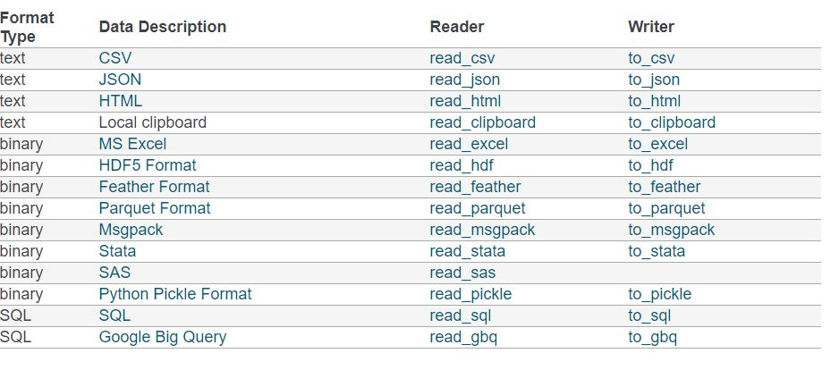

## Loading and Saving Data with Pandas

- importing from excel

```python
import pandas as pd
import numpy as np

data=pd.read_excel("./Lab/Datasets/cars.xlsx")
data.head()
```

```
##    Year  Month Manufacturer              Model  Quantity
## 0  2007      1  Volkswagen   Volkswagen Passat      1267
## 1  2007      1      Toyota         Toyota Rav4       819
## 2  2007      1      Toyota      Toyota Avensis       787
## 3  2007      1  Volkswagen     Volkswagen Golf       720
## 4  2007      1      Toyota      Toyota Corolla       691
```

## Writing data

- df.to_filetype(filename)

```python
data.to_csv("./Lab/Datasets/CarsCSV.csv")
```

## Lab

Take Master.csv file, import it and export only 10 rows to excel file called Master10.xlsx.

## Basic exploratory commands

- df.head(n): n first rows
- df.tail(n): n last rows
- df.shape: the number of rows and columns
- df.info(): the index, datatype and memory information
- s.value_counts(dropna=False): would allow you to view unique values and counts for a series
- df.describe(): summary statistics for numerical columns
- df.corr(): correlation between columns in a data frame

## Lab

Take master.csv file and answer:  
- How many unique weight values are present in DF?  
- How many rows and columns does the DF have?  
- How much memory does DF use?  
- Perform summary statistics for numerical columns. What is the mean and std of the height column?  
- What is the correlation between hright and weight?

## Complete detailed data investigation

- pandas_profiling module
- df.profile_report()
- lab: use profile_report() on master.csv and report findings

## Similar librariers to pandas_profiling

- dtale
- sweetviz
- autoviz

## Subsetting

- df[col]: return column with label col as Series
- df[[col1, col2]]: returns columns as a new DataFrame
- df.iloc[0,:]: selecting first row
- df.iloc[0,0]: selecting the first element of the first column

## Filter, sort and groupby

- df[df[column] > value]: all rows where column is greater than value
- &: and ; |: or; df[**(**df[column1] > value1**)** & **(**df[column2<value2]**)**]
- df.sort_values(column1): sorting DF by column1 ASC (default)
- df.sort_values(column2,ascending=False): sorting DF by column1 DESC
- df.sort_values([column1,column2],ascending=[True,False]): sorting by 2 columns
- df.groupby(column): involves splitting the data into groups based on some criteria, applying a function to each group independently and combining the results into a data structure
- df.groupby([column1,column2])

## Renaming

- df.rename()
- (index=index_mapper, columns=columns_mapper, …)
- df.rename(index=str, {columns={“A”: “a”, “B”: “c”})
- (mapper, axis={‘index’, ‘columns’}, …)
- df.rename({“A”: “a”, “C”: “c”}, axis=‘columns’)
- df.rename(columns={“A”: “a”, “C”: “c”})

## Lab

- Calculate players’ mean height and mean weight by birthState for players, who were born in USA after 1950.
- Print only birthState, mean height and weight sorted by birthState DESC.
- HINT: df.mean() returns mean for all columns.
- Rename columns to State, AverageW and AverageH.

## Solution

- columns=[“birthCountry”,“birthState”,“birthYear”,“height”,“weight”]
- selecting columns:df1=df[columns]
- selecting rows: df1=df1[(df[“birthCountry”]==“USA”) & (df[“birthYear”]>1950)]
- grouping and calculating mean: df1=df1.groupby(“birthState”).mean().iloc[:,1:3]
- sorting: df1=df1.sort_values(“birthState”,ascending=False)
- renaming: df1.rename(columns={“height”:“AVheight”,“weight”:“AVweight”})

## Skewness, kurtosis and histogram - 1

- pandas.skew()
- pandas.kurtosis()

```python
import pandas as pd
import numpy as np

data=pd.read_excel("./Lab/Datasets/cars.xlsx")
data["Quantity"].skew()
```

```
## 3.0791748573745044
```

```python
data["Quantity"].kurtosis()
```

```
## 16.05055015672574
```

## Skewness, kurtosis and histogram - 2

- pandas.hist()

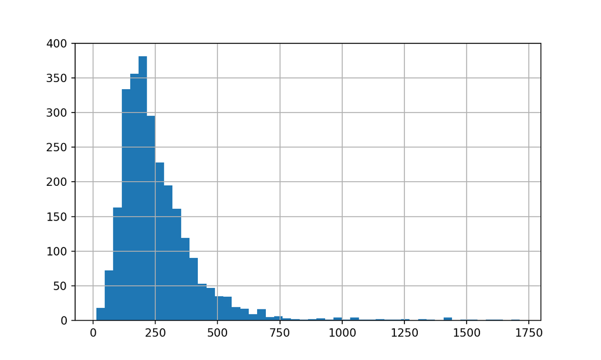

```python
import pandas as pd
import numpy as np
import matplotlib.pyplot as plt

data=pd.read_excel("./Lab/Datasets/cars.xlsx")
data["Quantity"].hist(bins=50)
```

## Data Cleaning

- pd.isnull(): checking for null values
- df[df.column.isnull()]: returns DF with rows, where column has null values
- pd.isnull().sum(): how many null values
- df.dropna(): drop missing values (rows) (axis=1 columns)
- df.fillna(x): replace missing values with x
- s.fillna(s.mean()): replace missing values with the mean
- df.column.fillna(df.column.mean(), inplace=True): replacing null values in column with mean of this column and saving the result immediately (inplace=True)

## Lab

- Show 10 rows of Master DF, where weight is null.
- Replace null values in weight column with average.
- Print the average value and the 20th row from Master DF.

## Solution

- selecting columns: df[df.weight.isnull()].head(10)
- calculating average: averageW=df[“weight”].mean()
- replacing with inplace: df.weight.fillna(averageW, inplace=True)
- printing: df.iloc[20,:]

## Calculated columns

- df[calculated_column]=df[column1]+df[column2]: new column is the sum of two existing columns
- df[calculated_column]=df.column1*df.column2: new column is the product of two existing columns
- df[calculated_column]=pow(df.column1, 2): new column is the power of two of the column1

## Lab

- Take birthCountry, height and weight from the Master DF.
- Replace NA with average values of height and weight.
- Tranform weight from pounds to kg and height from inches to meters
- Calculate BMI and show 10 rows
- Calculate average BMI index by birthCountry, sort by birthCountry

## Solution

- averageW=df[“weight”].mean()
- averageH=df[“height”].mean()
- df.weight.fillna(averageW, inplace=True)
- df.height.fillna(averageH, inplace=True)
- df[“weightKG”]=df.weight/2.2
- df[“heightCM”]=df.height*2.54
- df[“BMI”]=df[“weightKG”]/(df[“heightCM”]/100*df[“heightCM”]/100)
- df1=df[[“birthCountry”,“weightKG”,“heightCM”,“BMI”]]
- df1=df1.groupby(“birthCountry”).mean()
- df1.sort_values(“birthCountry”)

## Using apply and lambda with pandas

- more complex logic, i.e. combining multiple columns:

```
def someStupidLogic(birthYear,birthCountry,birthState):
    if birthYear<1950 and not pd.isnull(birthCountry):
        result=str(birthYear)+" "+birthCountry
    elif birthYear<2000 and birthYear>=1950 and not pd.isnull(birthState):
        result=str(birthYear)+" "+birthState
    else:
        result=str(birthYear)+" Random place"
    return result

df["someStupidLogic"]=df.apply(lambda x:
someStupidLogic(x["birthYear"],
                x["birthCountry"],
                x["birthState"])
                         ,axis=1)
```

## Using GUI to modify pandas

- pandasgui package

```
from pandasgui import show
from pandasgui.datasets import titanic

#Run gui
gui = show(titanic)
#getting back the modifications
gui.get_dataframes()['titanic']
```

## Reshape pandas with pivot (1)

- long to wide

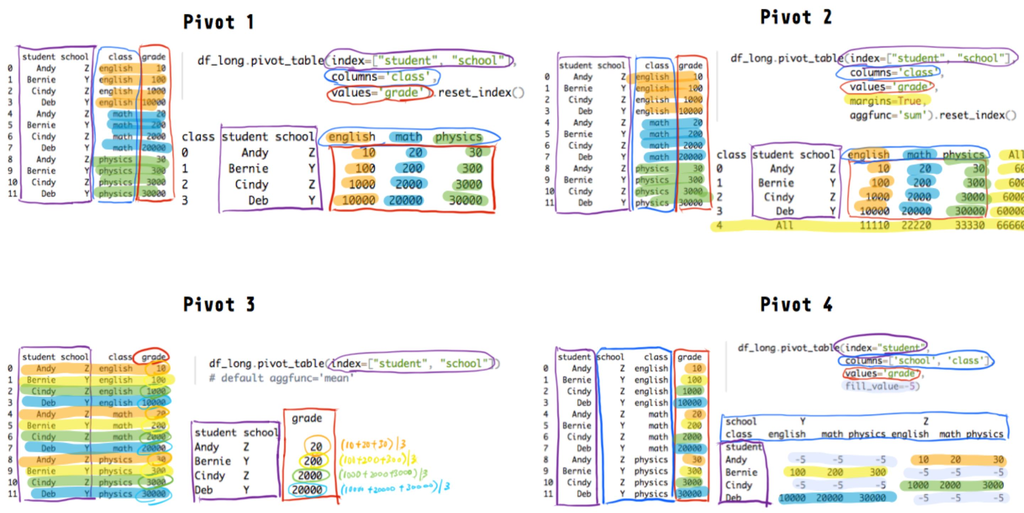

## Reshape pandas with pivot (2)

```python
df_long = pd.DataFrame({
        "student":
            ["Andy", "Bernie", "Cindy", "Deb",
             "Andy", "Bernie", "Cindy", "Deb",
             "Andy", "Bernie", "Cindy", "Deb"],
        "school":
            ["Z", "Y", "Z", "Y",
             "Z", "Y", "Z", "Y",
             "Z", "Y", "Z", "Y"],
        "class":
            ["english", "english", "english", "english",
             "math", "math", "math", "math",
             "physics", "physics", "physics", "physics"],
        "grade":
            [10, 100, 1000, 10000,
             20, 200, 2000, 20000,
             30, 300, 3000, 30000]})
```

## Reshape pandas with pivot (3)

```
##   student school    class  grade
## 0    Andy      Z  english     10
## 1  Bernie      Y  english    100
## 2   Cindy      Z  english   1000
## 3     Deb      Y  english  10000
## 4    Andy      Z     math     20
```

## Reshape pandas with pivot (4)

```python
df_long.pivot_table(index=["student", "school"], columns='class', values='grade').head(3)
```

```
## class           english  math  physics
## student school
## Andy    Z            10    20       30
## Bernie  Y           100   200      300
## Cindy   Z          1000  2000     3000
```

```python
df_long.pivot_table(index=["student", "school"], columns='class',
values='grade').reset_index().head(3)
```

```
## class student school  english  math  physics
## 0        Andy      Z       10    20       30
## 1      Bernie      Y      100   200      300
## 2       Cindy      Z     1000  2000     3000
```

## Reshape pandas with pivot (5)

```python
df_long.pivot_table(index=["student", "school"],
                    columns='class',
                    values='grade',
                    margins=True,  # add margins
                    aggfunc='mean').reset_index()  # mean margins (rows/columns)
```

```
## class student school  english   math  physics    All
## 0        Andy      Z     10.0     20     30.0     20
## 1      Bernie      Y    100.0    200    300.0    200
## 2       Cindy      Z   1000.0   2000   3000.0   2000
## 3         Deb      Y  10000.0  20000  30000.0  20000
## 4         All          2777.5   5555   8332.5   5555
```

## Reshape pandas with melt (1)

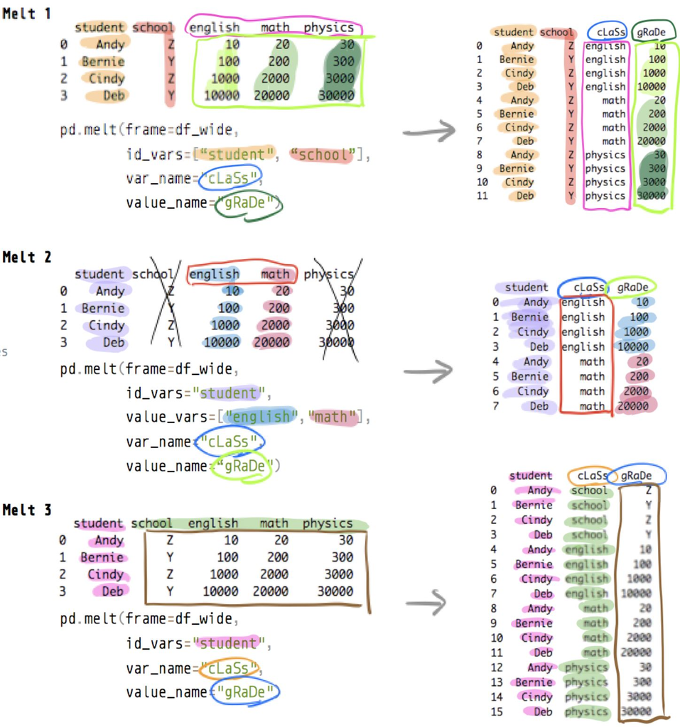

## Reshape pandas with melt (2)

```python
import pandas as pd
# create wide dataframe
df_wide = pd.DataFrame(
  {"student": ["Andy", "Bernie", "Cindy", "Deb"],
   "school":  ["Z", "Y", "Z", "Y"],
   "english": [10, 100, 1000, 10000],  # eng grades
   "math":    [20, 200, 2000, 20000],  # math grades
   "physics": [30, 300, 3000, 30000]   # physics grades
  }
)
```

## Reshape pandas with melt (3)

```
##   student school  english   math  physics
## 0    Andy      Z       10     20       30
## 1  Bernie      Y      100    200      300
## 2   Cindy      Z     1000   2000     3000
## 3     Deb      Y    10000  20000    30000
```

## Reshape pandas with melt (4)

```python
df_wide.melt(id_vars=["student", "school"],
             var_name="cLaSs",  # rename
             value_name="gRaDe").head(8)  # rename
```

```
##   student school    cLaSs  gRaDe
## 0    Andy      Z  english     10
## 1  Bernie      Y  english    100
## 2   Cindy      Z  english   1000
## 3     Deb      Y  english  10000
## 4    Andy      Z     math     20
## 5  Bernie      Y     math    200
## 6   Cindy      Z     math   2000
## 7     Deb      Y     math  20000
```

## Reshape pandas with melt (5)

- choosing columns for melt

```python
df_wide.melt(id_vars="student",
             value_vars=["english", "math"],
             var_name="cLaSs",  # rename
             value_name="gRaDe")
```

```
##   student    cLaSs  gRaDe
## 0    Andy  english     10
## 1  Bernie  english    100
## 2   Cindy  english   1000
## 3     Deb  english  10000
## 4    Andy     math     20
## 5  Bernie     math    200
## 6   Cindy     math   2000
## 7     Deb     math  20000
```

## Lab

Take a Master.csv (playerID, birthCountry, weight) where birthCountry is Poland, Sweden and Norway. Pivot data and show it. Melt it and show it.

## Solution

```
import pandas as pd

data=pd.read_csv("./Lab/Datasets/Master.csv")
df=data[data['birthCountry'].isin(["Poland", "Sweden",
"Norway"])][['playerID', 'birthCountry', 'weight']]

pivotdf=df.pivot_table(index="playerID", columns='birthCountry',
values='weight').reset_index()

pivotdf

meltdf=pivotdf.melt(id_vars="playerID",
             var_name="Country",  # rename
             value_name="weightInPounds")

meltdf[meltdf["weightInPounds"].notnull()].sort_values("playerID")
```

## Merge dataframes

- database-style DataFrame or named Series joining/merging
- pd.merge
- default: inner join
- result = pd.merge(left, right, on=‘key’, how=“inner”)
- joining on many columns: pd.merge(left, right, on=[column1, column2])
- joining on many columns with different names: pd.merge(left, right, left_on==[column1, column2], right_on= [column3, column4])

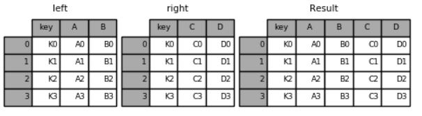

## Example

```python
import numpy as np
import pandas as pd

df1 = pd.DataFrame({'ID': [1,2,3,4,5,6], 'pID' : [21,22,23,24,25,26],
'Values1' : [435,33,45,34,57,12]})

df2 = pd.DataFrame({'ID' : [4,4,5], 'pid' : [24,25,25],
'Values2' : [544, 545, 676]})

result=pd.merge(df1, df2, left_on=['ID', 'pID'], right_on=['ID', 'pid'])

print(result)
```

```
##    ID  pID  Values1  pid  Values2
## 0   4   24       34   24      544
## 1   5   25       57   25      676
```

## Lab

Join Master.csv with HallOfFame.csv on playerID. Show the result(first 10 rows)!

## Solution

```python
import pandas as pd

df1=pd.read_csv("./Lab/Datasets/Master.csv")
df2=pd.read_csv("./Lab/Datasets/HallOfFame.csv")

df=pd.merge(df1, df2, on="playerID")
df.head(10)
```

```
##     playerID  birthYear  birthMonth  ...  inducted category needed_note
## 0  aaronha01     1934.0         2.0  ...         Y   Player         NaN
## 1  abbotji01     1967.0         9.0  ...         N   Player         NaN
## 2  adamsba01     1882.0         5.0  ...         N   Player         NaN
## 3  adamsba01     1882.0         5.0  ...         N   Player         NaN
## 4  adamsba01     1882.0         5.0  ...         N   Player         NaN
## 5  adamsba01     1882.0         5.0  ...         N   Player         NaN
## 6  adamsba01     1882.0         5.0  ...         N   Player         NaN
## 7  adamsba01     1882.0         5.0  ...         N   Player      Top 20
## 8  adamsba01     1882.0         5.0  ...         N   Player         NaN
## 9  adamsba01     1882.0         5.0  ...         N   Player         NaN
##
## [10 rows x 32 columns]
```

## Seaborn

## Modules

- Matplotlib
- Seaborn: targets statistical data visualization
- Seaborn is complimentary to Matplotlib
- Seaborn:
  - creates aesthetically pleasing plots by default
  - creates statistically meaningful plots
  - understands the pandas DataFrame
  - is not directly included in Anaconda’s release

## Seaborn plots

- broadly divided into two classes:
  - “Axes-level” functions: regplot, boxplot, kdeplot
  - “Figure-level” functions: lmplot, factorplot, jointplot
- axes-level functions will only draw onto an axes and won’t otherwise mess with the figure
- figure level: the functions need to have total control over the figure
- figure level: fig and axes arguments, customization has to come after you’ve called the function

## Statistically meaningful plots

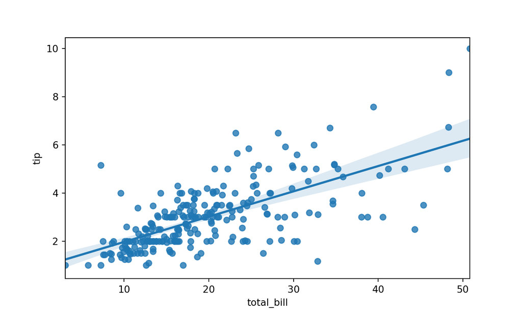

## Linear regression

- lmplot
- regplot
- parameters:
  - hue: color by categories
  - col/row: facets
  - fit_reg: regression line
  - ci: confidential intervals
  - order: polyinominal fitting curve

## Tips dataset

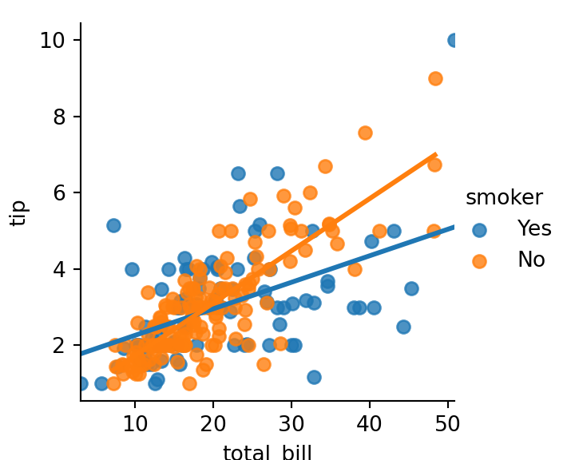

```python
tips = sns.load_dataset("tips")
lm=sns.lmplot(x="total_bill", y="tip", hue="smoker", data=tips, ci=None, size=3)
```

## Additional meta data through matplotlib

[figure not shown]

```python
plt.title('Total bill vs. tip')
# Set x-axis label
plt.xlabel('Total bill')
plt.ylabel('Tip ($)')
```

## Facet - col

- defining how and by what: col or row

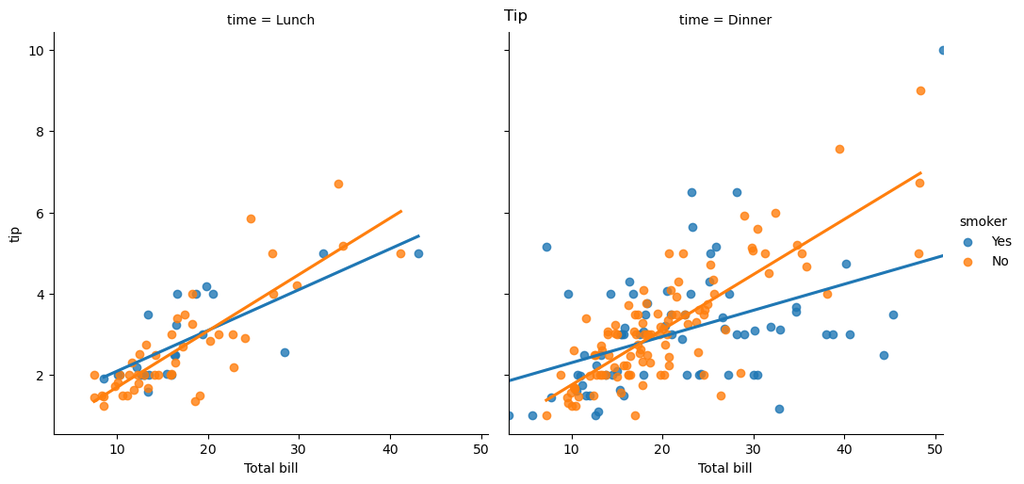

[figure not shown]

```python
lm=sns.lmplot(x="total_bill", y="tip", hue="smoker",
data=tips, col="time", ci=None)
lm.fig.suptitle("Tip")
lm.set_axis_labels("Total bill")
```

## Facet - row

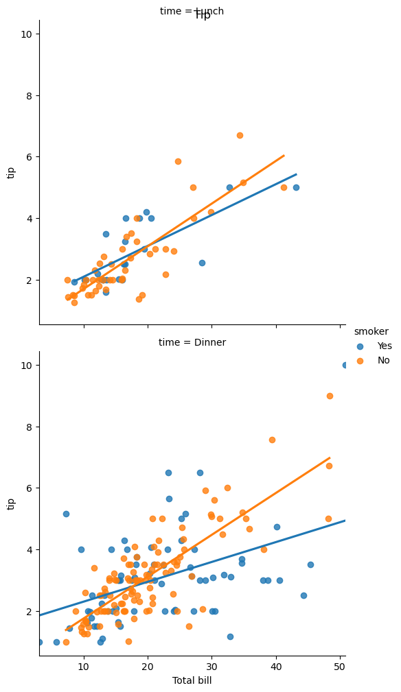

[figure not shown]

```python
lm=sns.lmplot(x="total_bill", y="tip", hue="smoker",
data=tips, row="time", ci=None)
lm.fig.suptitle("Tip")
lm.set_axis_labels("Total bill")
```

## Barchart (1)

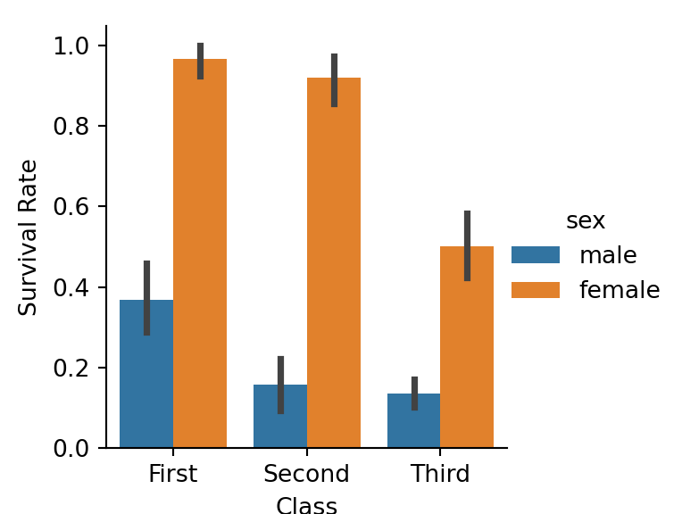

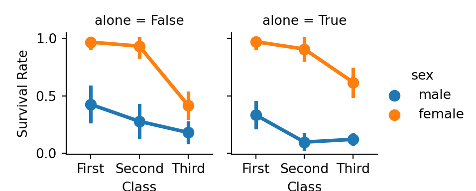

## Lab

Import CarsCSV.csv and show Quantity by Manufacturer and Year (facet). Show only data for Volkswagen, Toyota and Skoda for year 2007 and 2008. Mind the whitespace after the value in columns. Use str.strip() to trim.

## Solution

```
import seaborn as sns
import matplotlib.pyplot as plt
import pandas as pd

df=pd.read_csv("./Lab/Datasets/CarsCSV.csv")

df=df[["Year","Manufacturer","Quantity"]]

df=df[(df["Manufacturer"].str.strip()=="Toyota") |
(df["Manufacturer"].str.strip()=="Volkswagen") |
(df["Manufacturer"].str.strip()=="Skoda")]

df=df[(df["Year"]==2007) | (df["Year"]==2008)]

df=df.groupby(["Manufacturer","Year"], as_index=False).sum()

sns.catplot(x="Manufacturer", y="Quantity",  kind="bar", col="Year", data=df, height=3)
```

## Interactive plot with plotly

- install plotly
- copy this code to jupyter

```
import plotly.express as px
df = px.data.tips()
fig = px.scatter(df, x="total_bill", y="tip", color='sex', facet_col="day")
fig.update_xaxes(matches=None)
fig.show()
```

## Statsmodels

## Statsmodels

- statistical models:
  - Linear regression models
  - Discrete models
  - Time Series Analysis
  - Survival analysis
  - Nonparametric statistics …

## Summary statistics (1)

```python
sampleDF.head(10)
```

```
##           x         y
## 0  0.000000 -0.501081
## 1  0.101010  0.695681
## 2  0.202020  1.497106
## 3  0.303030  1.306623
## 4  0.404040  3.730396
## 5  0.505051  4.015650
## 6  0.606061  4.815687
## 7  0.707071  6.346889
## 8  0.808081  8.218514
## 9  0.909091  9.999710
```

```python
model = sm.OLS(sampleDF["y"], sampleDF["x"])
results = model.fit()
```

## Summary statistics (2)

```python
print(results.summary())
```

```
##                                  OLS Regression Results
## =======================================================================================
## Dep. Variable:                      y   R-squared (uncentered):                   0.938
## Model:                            OLS   Adj. R-squared (uncentered):              0.938
## Method:                 Least Squares   F-statistic:                              1504.
## Date:                Mon, 20 Dec 2021   Prob (F-statistic):                    1.15e-61
## Time:                        15:56:34   Log-Likelihood:                         -614.02
## No. Observations:                 100   AIC:                                      1230.
## Df Residuals:                      99   BIC:                                      1233.
## Df Model:                           1
## Covariance Type:            nonrobust
## ==============================================================================
##                  coef    std err          t      P>|t|      [0.025      0.975]
## ------------------------------------------------------------------------------
## x             75.6190      1.950     38.776      0.000      71.749      79.489
## ==============================================================================
## Omnibus:                       18.675   Durbin-Watson:                   0.003
## Prob(Omnibus):                  0.000   Jarque-Bera (JB):               23.033
## Skew:                           1.163   Prob(JB):                     9.96e-06
## Kurtosis:                       3.343   Cond. No.                         1.00
## ==============================================================================
##
## Notes:
## [1] R² is computed without centering (uncentered) since the model does not contain a constant.
## [2] Standard Errors assume that the covariance matrix of the errors is correctly specified.
```

## Summary statistics (3)

```python
import statsmodels.api as sms
import numpy as np
import statsmodels.formula.api as smf

dat = sms.datasets.get_rdataset("Guerry", "HistData").data

df=dat.iloc[:,[5,16,22]]

results = smf.ols('Lottery ~ Literacy + np.log(Pop1831)', data=dat).fit()
```

## Summary statistics (4)

```python
print(results.summary())
```

```
##                             OLS Regression Results
## ==============================================================================
## Dep. Variable:                Lottery   R-squared:                       0.348
## Model:                            OLS   Adj. R-squared:                  0.333
## Method:                 Least Squares   F-statistic:                     22.20
## Date:                Mon, 20 Dec 2021   Prob (F-statistic):           1.90e-08
## Time:                        15:56:38   Log-Likelihood:                -379.82
## No. Observations:                  86   AIC:                             765.6
## Df Residuals:                      83   BIC:                             773.0
## Df Model:                           2
## Covariance Type:            nonrobust
## ===================================================================================
##                       coef    std err          t      P>|t|      [0.025      0.975]
## -----------------------------------------------------------------------------------
## Intercept         246.4341     35.233      6.995      0.000     176.358     316.510
## Literacy           -0.4889      0.128     -3.832      0.000      -0.743      -0.235
## np.log(Pop1831)   -31.3114      5.977     -5.239      0.000     -43.199     -19.424
## ==============================================================================
## Omnibus:                        3.713   Durbin-Watson:                   2.019
## Prob(Omnibus):                  0.156   Jarque-Bera (JB):                3.394
## Skew:                          -0.487   Prob(JB):                        0.183
## Kurtosis:                       3.003   Cond. No.                         702.
## ==============================================================================
##
## Notes:
## [1] Standard Errors assume that the covariance matrix of the errors is correctly specified.
```